# Prediction Assignment

JRobertsDS

7/2/2020

# Executive Summary

This document is available via html here: https://rpubs.com/JRobertsDS/Prediction

For this project, we were supplied measurements from subjects while they were doing exercises, classified into five categories depending on the manner in which the subjects were performing the exercises. Our goal was to predict which categories were most likely to apply to 20 new sets of measurements, which were also supplied.

Steps taken:

- Set up for reproducibility
- Load the data
- Exploratory Analysis
- Clean the data by reducing redundant and extraneous data Normalize, scale, remove near zero variance data, and impute missing values with K nearest neighbors
- Compute a Random Forest prediction algorithm via the Caret package in R, given the training data supplied
- Explore the Random Forest
- Conclusion: predict values for the testing data supplied

# Set up for reproducibility

```r
set.seed (1234)
```

# Load Data

```r
#download.file ("https://d396qusza40orc.cloudfront.net/predmachlearn/pml-training.csv", "pml-training.csv", method = "curl")
#download.file ("https://d396qusza40orc.cloudfront.net/predmachlearn/pml-testing.csv", "pml-testing.csv", method = "curl")
rawTraining <- read.csv ("pml-training.csv")
rawTesting <- read.csv ("pml-testing.csv")
```

# Exploratory Analysis

```r
str (rawTraining[, 1:10])
```

```
## 'data.frame':    19622 obs. of  10 variables:
##  $ X                   : int  1 2 3 4 5 6 7 8 9 10 ...
##  $ user_name           : Factor w/ 6 levels "adelmo","carlitos",..: 2 2 2 2 2 2 2 2 2 2 ...
##  $ raw_timestamp_part_1: int  1323084231 1323084231 1323084231 1323084232 1323084232 1323084232 1323084232 1323084232 1323084232 1323084232 ...
##  $ raw_timestamp_part_2: int  788290 808298 820366 120339 196328 304277 368296 440390 484323 484434 ...
##  $ cvtd_timestamp      : Factor w/ 20 levels "02/12/2011 13:32",..: 9 9 9 9 9 9 9 9 9 9 ...
##  $ new_window          : Factor w/ 2 levels "no","yes": 1 1 1 1 1 1 1 1 1 1 ...
##  $ num_window          : int  11 11 11 12 12 12 12 12 12 12 ...
##  $ roll_belt           : num  1.41 1.41 1.42 1.48 1.48 1.45 1.42 1.42 1.43 1.45 ...
##  $ pitch_belt          : num  8.07 8.07 8.07 8.05 8.07 8.06 8.09 8.13 8.16 8.17 ...
##  $ yaw_belt            : num  -94.4 -94.4 -94.4 -94.4 -94.4 -94.4 -94.4 -94.4 -94.4 -94.4 ...
```

```r
head (names (rawTraining), 40)
```

```
##  [1] "X"                    "user_name"            "raw_timestamp_part_1"
##  [4] "raw_timestamp_part_2" "cvtd_timestamp"       "new_window"
##  [7] "num_window"           "roll_belt"            "pitch_belt"
## [10] "yaw_belt"             "total_accel_belt"     "kurtosis_roll_belt"
## [13] "kurtosis_picth_belt"  "kurtosis_yaw_belt"    "skewness_roll_belt"
## [16] "skewness_roll_belt.1" "skewness_yaw_belt"    "max_roll_belt"
## [19] "max_picth_belt"       "max_yaw_belt"         "min_roll_belt"
## [22] "min_pitch_belt"       "min_yaw_belt"         "amplitude_roll_belt"
## [25] "amplitude_pitch_belt" "amplitude_yaw_belt"   "var_total_accel_belt"
## [28] "avg_roll_belt"        "stddev_roll_belt"     "var_roll_belt"
## [31] "avg_pitch_belt"       "stddev_pitch_belt"    "var_pitch_belt"
## [34] "avg_yaw_belt"         "stddev_yaw_belt"      "var_yaw_belt"
## [37] "gyros_belt_x"         "gyros_belt_y"         "gyros_belt_z"
## [40] "accel_belt_x"
```

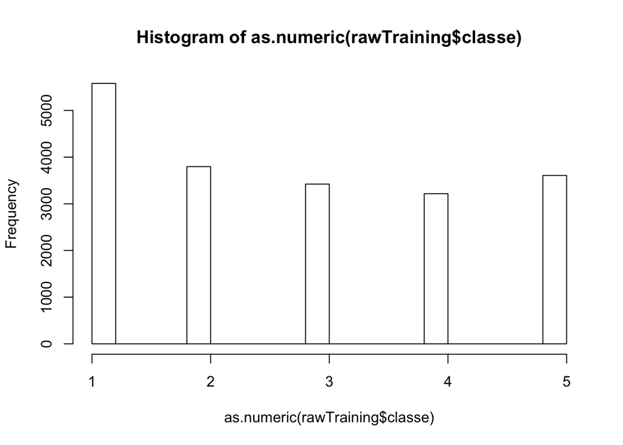

```r
hist (as.numeric (rawTraining$classe))
```

# Clean Data

```r
colsToRemove <- c("avg", "stddev", "max", "min", "var", "raw", "user", "X", "time", "kurtosis", "skewness", "amplitude_yaw")
training <- select (rawTraining, -contains (colsToRemove))
testing <- select (rawTesting, -contains (colsToRemove))
preTrain <- preProcess (training, method = c("center", "scale", "nzv", "knnImpute"))
trainData <- predict (preTrain, training)
testData <- predict (preTrain, testing)
```

# Compute Random Forest

```r
forestFit <- readRDS ("forestFit.RDS") # read manually cached results, so they don't have to be re-computed each Knit
#forestFit <- train (classe ~ ., method = "rf", verbose = FALSE, data = trainData, na.action = na.omit)
#   saveRDS (forestFit, file="forestFit.RDS")
```

# Explore the Random Forest

```r
preTrain
```

```
## Created from 406 samples and 51 variables
##
## Pre-processing:
##   - centered (46)
##   - ignored (2)
##   - 5 nearest neighbor imputation (46)
##   - removed (3)
##   - scaled (46)
```

```r
#forestFit$finalModel

# In band accuracy
forestTrainPredictions <- predict (forestFit, trainData)
forestTrainAccuracy <- (sum (trainData$classe == forestTrainPredictions)) / length (forestTrainPredictions)
forestTrainAccuracy
```

```
## [1] 1
```

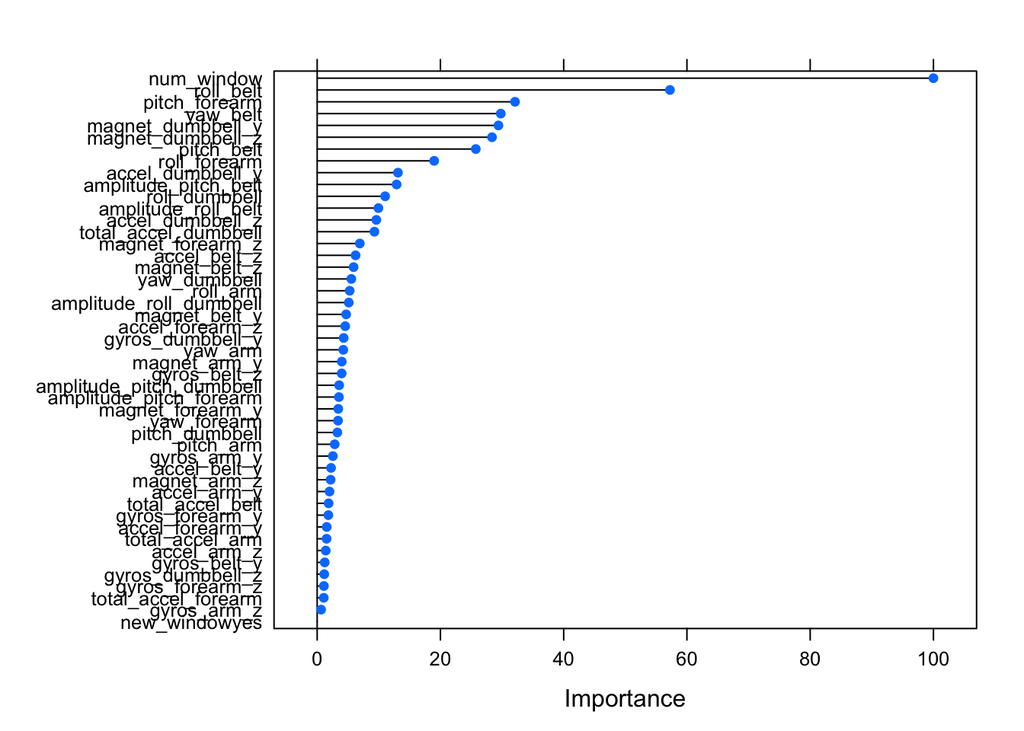

```r
# Variable Importance
forestImp <- varImp (forestFit)
plot (forestImp)
```

# Conclusion

These are the predictions generated on the test data:

```r
# forestTestPredictions   [1] B A B A A E D B A A B C B A E E A B B B
forestTestPredictions <- predict (forestFit, testData)
forestTestPredictions
```

```
##  [1] B A B A A E D B A A B C B A E E A B B B
## Levels: A B C D E
```

Data source: http://web.archive.org/web/20161224072740/http:/groupware.les.inf.puc-rio.br/har